# Analiza składu jeziora

## 14. Metody regularyzacji (Ridge i Lasso)

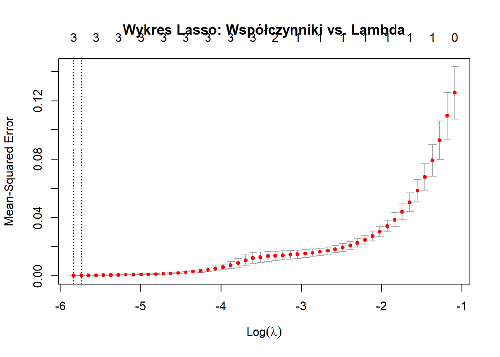

```r
x <- as.matrix(dane[, c("chla", "temp", "bar", "nas", "przew", "ph", "namon")])
y <- dane$ITS
model_lasso <- cv.glmnet(x, y, alpha = 1) # Lasso
model_ridge <- cv.glmnet(x, y, alpha = 0) # Ridge

# Wykres dla modelu Lasso
plot(model_lasso)
title("Wykres Lasso: Współczynniki vs. Lambda")
```

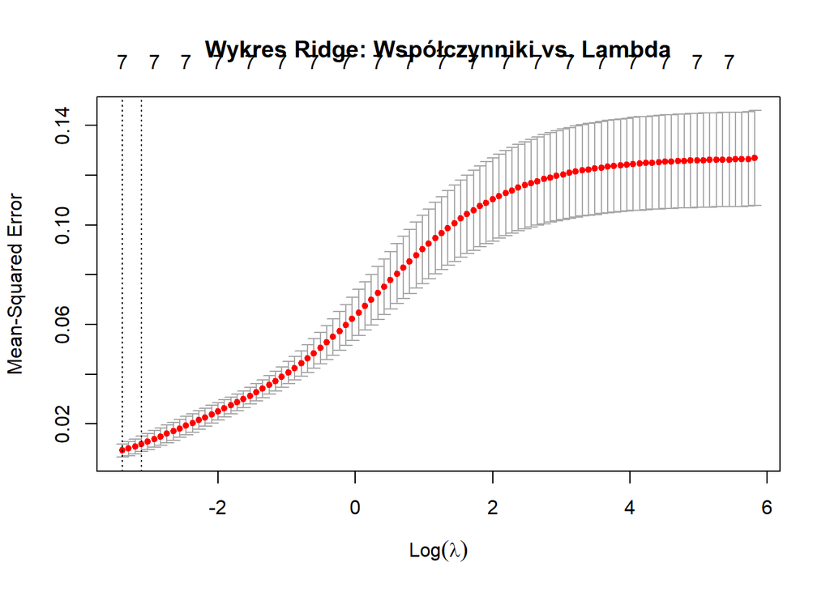

```r
# Wykres dla modelu Ridge
plot(model_ridge)
title("Wykres Ridge: Współczynniki vs. Lambda")
```

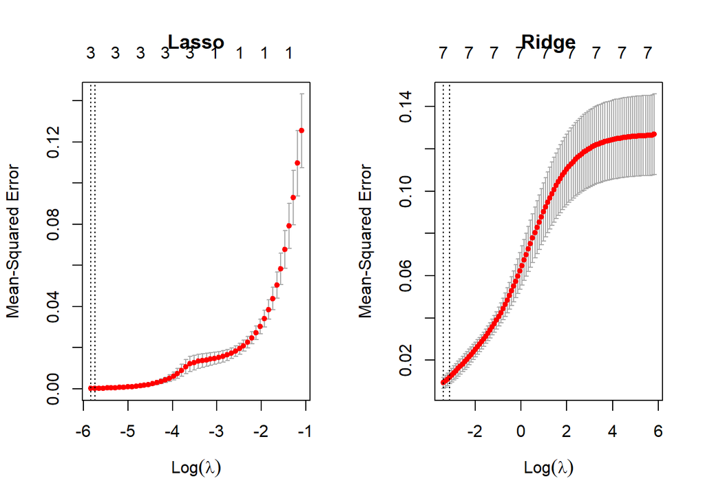

```r
# Alternatywnie, porównanie obu modeli na jednym wykresie
par(mfrow = c(1,2)) # Ustawienie dwóch wykresów obok siebie

plot(model_lasso, main = "Lasso")
plot(model_ridge, main = "Ridge")
```

```r
par(mfrow = c(1,1)) # Resetowanie ustawienia wykresów
```

**Optymalne λ:**

Na wykresach można zauważyć wartość λ, która minimalizuje MSE (najlepszy kompromis między prostotą modelu a jego dopasowaniem). Jest to wartość, przy której model jest najlepiej dopasowany bez przeuczenia.

**Regularyzacja:** Ridge lepiej radzi sobie z dużą liczbą skorelowanych zmiennych, ponieważ zachowuje wszystkie cechy. Lasso eliminuje nieistotne zmienne, co upraszcza model.

**Wybór metody:** W zależności od danych i celu analizy należy wybrać odpowiednią metodę: Lasso: Gdy kluczowe jest uproszczenie modelu. Ridge: Gdy każda zmienna wnosi istotną informację.

## 15. Gam model

```r
gam_model <- gam(ITS ~ s(chla) + s(temp) + s(nas) + s(przew), data = dane)
summary(gam_model)
```

```
Family: gaussian
Link function: identity

Formula:
ITS ~ s(chla) + s(temp) + s(nas) + s(przew)

Parametric coefficients:
            Estimate Std. Error t value Pr(>|t|)
(Intercept)  8.29377    0.02424   342.1   <2e-16 ***
---
Signif. codes:  0 '***' 0.001 '**' 0.01 '*' 0.05 '.' 0.1 ' ' 1

Approximate significance of smooth terms:
           edf Ref.df      F  p-value
s(chla)  1.000  1.000  1.311   0.2593
s(temp)  4.286  5.165  8.480 1.81e-05 ***
s(nas)   2.483  3.016 14.198 2.44e-06 ***
s(przew) 4.175  4.869  3.319   0.0161 *
---
Signif. codes:  0 '***' 0.001 '**' 0.01 '*' 0.05 '.' 0.1 ' ' 1

R-sq.(adj) =  0.763   Deviance explained =   82%
GCV = 0.040168  Scale est. = 0.029973  n = 51
```

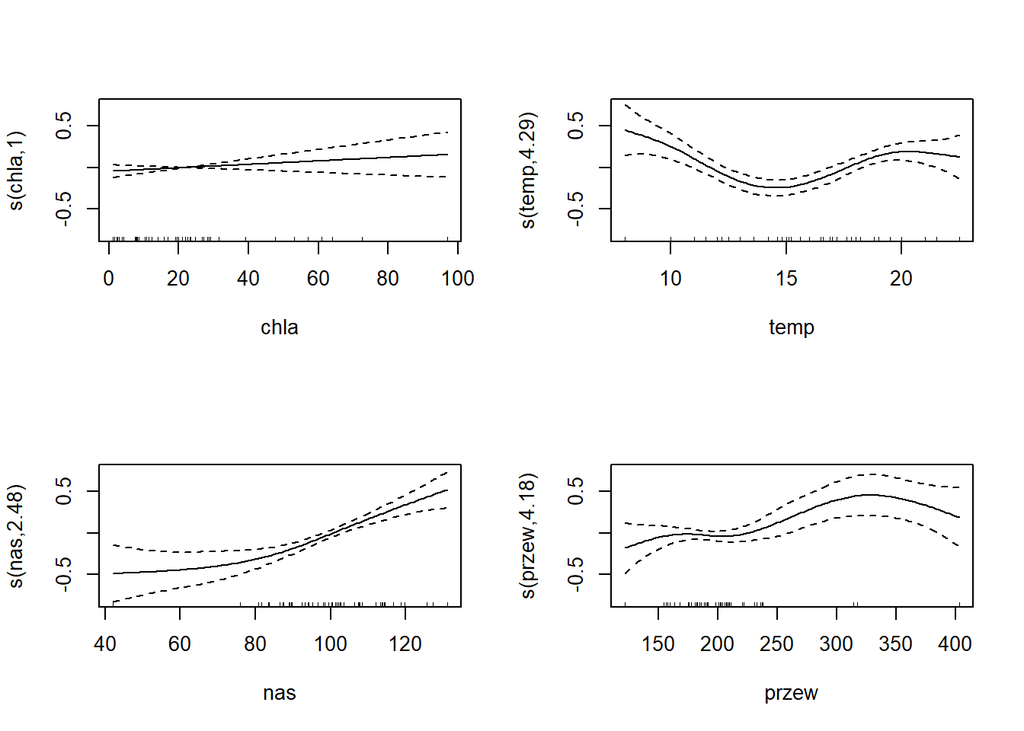

```r
# Wizualizacja nieliniowych efektów
plot(gam_model, pages = 1)
```

## 16. Inne wykresy

### 16.1 Zależność między chlorofilem a ITS

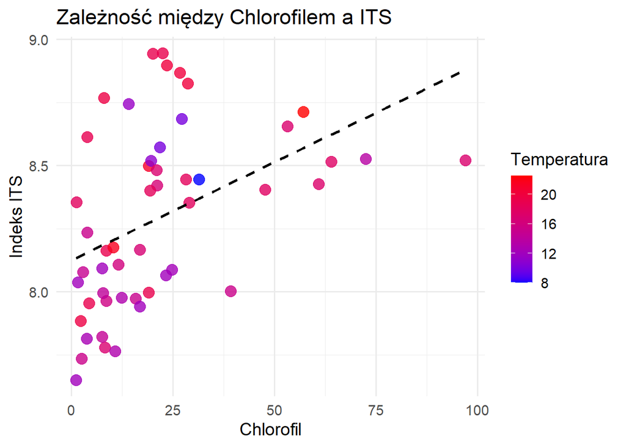

```r
ggplot(dane, aes(x = chla, y = ITS, color = temp)) +
  geom_point(size = 4, alpha = 0.8) +
  geom_smooth(method = "lm", se = FALSE, color = "black", linetype = "dashed") +
  scale_color_gradient(low = "blue", high = "red", name = "Temperatura") +
  labs(title = "Zależność między Chlorofilem a ITS",
       x = "Chlorofil",
       y = "Indeks ITS") +
  theme_minimal(base_size = 14) +
  theme(legend.position = "right")
```

- Zależność między stężeniem chlorofilu-a a indeksem ITS wydaje się dodatnia (wyższe stężenie chlorofilu jest związane z wyższym ITS)

### 16.2 Rozkład chlorofilu

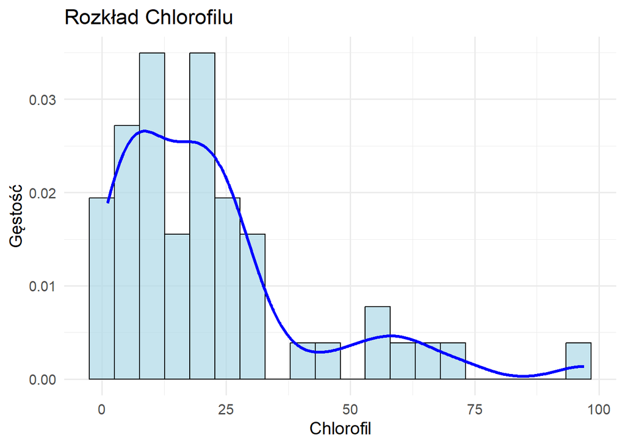

```r
ggplot(dane, aes(x = chla)) +
  geom_histogram(aes(y = after_stat(density)), bins = 20, fill = "lightblue", color = "black", alpha = 0.7) +
  geom_density(color = "blue", size = 1.2) +
  labs(title = "Rozkład Chlorofilu",
       x = "Chlorofil",
       y = "Gęstość") +
  theme_minimal(base_size = 14)
```

- Większość wartości stężenia chlorofilu-a znajduje się w dolnym zakresie (0–25), co może wskazywać na tendencję do niskich stężeń w zbiorze danych
- Obserwuje się pojedyncze wartości w wyższych zakresach (np. powyżej 75), co może być wynikiem specyficznych warunków środowiskowych lub odchyleń

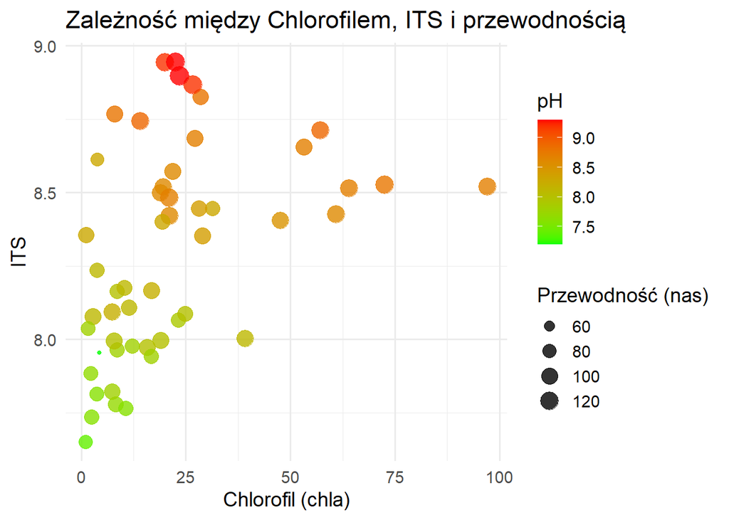

```r
ggplot(dane, aes(x = chla, y = ITS, size = nas, color = ph)) +
  geom_point(alpha = 0.8) +
  scale_color_gradient(low = "green", high = "red", name = "pH") +
  labs(title = "Zależność między Chlorofilem, ITS i przewodnością",
       x = "Chlorofil (chla)",
       y = "ITS",
       size = "Przewodność (nas)") +
  theme_minimal(base_size = 14) +
  theme(legend.position = "right")
```

### 16.4 Rozkład ITS w różnych kategoriach wody

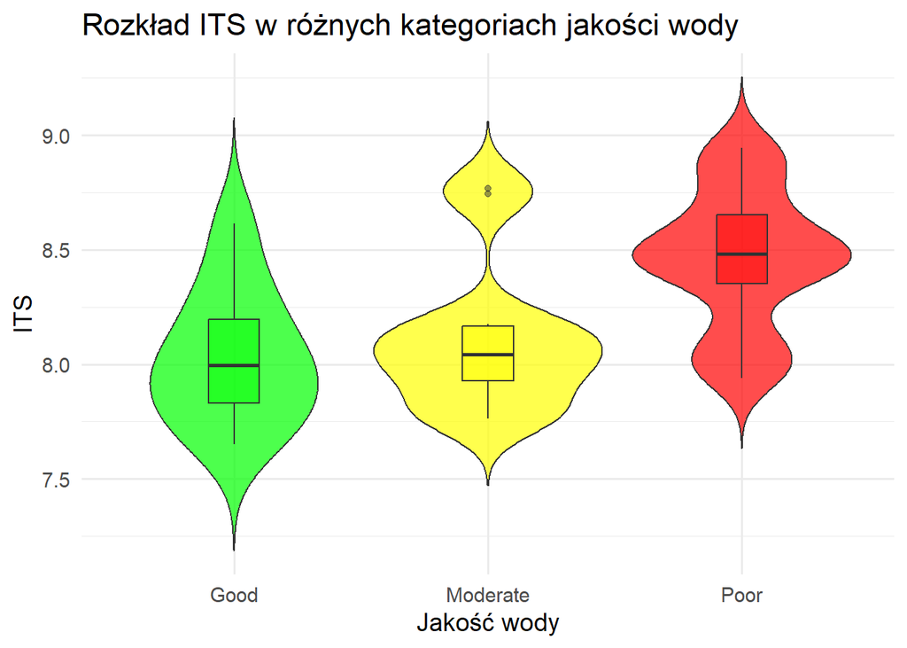

```r
# Podział na kategorie jakości wody
dane$quality <- cut(dane$chla, breaks = c(-Inf, 5, 15, Inf), labels = c("Good", "Moderate", "Poor"))

ggplot(dane, aes(x = quality, y = ITS, fill = quality)) +
  geom_violin(trim = FALSE, alpha = 0.7) +
  geom_boxplot(width = 0.2, alpha = 0.5) +
  scale_fill_manual(values = c("Good" = "green", "Moderate" = "yellow", "Poor" = "red")) +
  labs(title = "Rozkład ITS w różnych kategoriach jakości wody",
       x = "Jakość wody",
       y = "ITS") +
  theme_minimal(base_size = 14) +
  theme(legend.position = "none")
```

- Wykres skrzypcowy ilustruje, że ITS jest najwyższy dla wody o słabej jakości, a najniższy dla wody o dobrej jakości. Woda o umiarkowanej jakości ma ITS pomiędzy tymi wartościami. Rozkład sugeruje, że jakość wody może być skorelowana z ITS